# Comprehensive USA Customer Transaction Analysis and Predictive Modeling

## Comprehensive USA Customer Transaction Analysis And Predictive Modeling

#### Introduction

Welcome to the "Comprehensive USA Customer Transaction Analysis And Predictive Modeling" project! Here, I take you on a journey through the intricate world of customer transactions, focusing specifically on the USA market. As the sole creator of this project, I've seamlessly merged tables, preprocessed data, engineered features, conducted exploratory data analysis (EDA), visualized patterns, and employed machine learning techniques for prediction. This project is a solo endeavor, showcasing a harmonious blend of analytical techniques to derive meaningful insights and predictions from a rich dataset.

### Project Overview

#### 1. Data Merging

We kick off our journey by merging tables with common columns, bringing together diverse aspects of customer transactions.

#### 2. Data Preprocessing

Ensuring data quality and consistency through cleaning and preparation for downstream analysis.

#### 3. Feature Engineering

Crafting new features to extract additional insights and improve the predictive power of our models.

#### 4. Exploratory Data Analysis (EDA)

1.Unveiling the hidden stories within the data through a series of visualizations and analyses:

2.Visualizing the correlation matrix of numerical features.

3.Exploring the relationship between Avg_Price and GST through scatter plots.

4.Analyzing the distribution of categorical features (Gender, Location, Coupon_Status).

5.Investigating total sales over time.

6.Examining total transactions, total amount, and average discount percentage by product category and month.

7.Unveiling the monthly distribution of transactions, variation in total sales, and total amount by product category and gender.

#### 5. Machine Learning

Utilizing machine learning algorithms for predictive modeling:

1.Predicting Total_Amount using Linear Regression.

2.Predicting Coupon_Status using Logistic Regression.

3.Predicting Product_Category using RandomForestClassifier.

#### 6. Neural Network

Implementing a Neural Network for precise Product Category prediction.

### Column Details

CustomerID: Unique identifier for each customer.

Gender: Gender of the customer (M for male in the provided examples).

Location: Location or city where the transaction took place (e.g., Chicago).

Tenure_Months: Number of months the customer has been associated with the service.

Transaction_ID: Unique identifier for each transaction.

Transaction_Date: Date of the transaction (e.g., 2019-01-01).

Product_SKU: Stock-keeping unit for the product.

Product_Description: Detailed description of the product purchased.

Product_Category: Category to which the product belongs (e.g., Nest-USA).

Quantity: Quantity of the product purchased in the transaction.

Avg_Price: Average price of the product.

Delivery_Charges: Charges for delivering the product.

Transaction_Month: Month in which the transaction occurred (e.g., Jan for January).

Coupon_Status: Status of any coupon used in the transaction (e.g., Used).

Coupon_Code: Code associated with the used coupon (e.g., ELEC10).

Discount_pct: Percentage of discount applied to the transaction (e.g., 10.0).

```python
import pandas as pd
import numpy as np
import matplotlib.pyplot as plt
import seaborn as sns
import warnings
warnings.filterwarnings("ignore")
```

# 1. Data Merging:- Merging Tables with Common Columns

Merging tables with common columns is a data manipulation task that typically falls under the broader categories of "data manipulation" or "data preprocessing." Specifically, it is part of the process known as "data merging" or "data joining." This task involves combining two or more tables based on a common column or key to create a unified dataset.

### 1.customer table

```python
customer=pd.read_csv('C:\\Users\\rushi\\Downloads\\Current Project\\Customer.csv')
customer.head(2)
```

|  | CustomerID | Gender | Location | Tenure_Months |
| --- | --- | --- | --- | --- |
| 0 | 17850 | M | Chicago | 12 |
| 1 | 13047 | M | California | 43 |

```python
print(customer.info())
print(customer.isnull().sum())
```

```
<class 'pandas.core.frame.DataFrame'>
RangeIndex: 1468 entries, 0 to 1467
Data columns (total 4 columns):
 #   Column         Non-Null Count  Dtype
---  ------         --------------  -----
 0   CustomerID     1468 non-null   int64
 1   Gender         1468 non-null   object
 2   Location       1468 non-null   object
 3   Tenure_Months  1468 non-null   int64
dtypes: int64(2), object(2)
memory usage: 46.0+ KB
None
CustomerID       0
Gender           0
Location         0
Tenure_Months    0
dtype: int64
```

### 2.online_sales

```python
online_sales=pd.read_csv('C:\\Users\\rushi\\Downloads\\Current Project\\Online_Sales.csv')
online_sales.head(2)
```

|  | CustomerID | Transaction_ID | Transaction_Date | Product_SKU | Product_Description | Product_Category | Quantity | Avg_Price | Delivery_Charges | Coupon_Status |
| --- | --- | --- | --- | --- | --- | --- | --- | --- | --- | --- |
| 0 | 17850 | 16679 | 1/1/2019 | GGOENEBJ079499 | Nest Learning Thermostat 3rd Gen-USA - Stainle... | Nest-USA | 1 | 153.71 | 6.5 | Used |
| 1 | 17850 | 16680 | 1/1/2019 | GGOENEBJ079499 | Nest Learning Thermostat 3rd Gen-USA - Stainle... | Nest-USA | 1 | 153.71 | 6.5 | Used |

```python
print(online_sales.info())
print(online_sales.isnull().sum())
```

```
<class 'pandas.core.frame.DataFrame'>
RangeIndex: 52924 entries, 0 to 52923
Data columns (total 10 columns):
 #   Column               Non-Null Count  Dtype
---  ------               --------------  -----
 0   CustomerID           52924 non-null  int64
 1   Transaction_ID       52924 non-null  int64
 2   Transaction_Date     52924 non-null  object
 3   Product_SKU          52924 non-null  object
 4   Product_Description  52924 non-null  object
 5   Product_Category     52924 non-null  object
 6   Quantity             52924 non-null  int64
 7   Avg_Price            52924 non-null  float64
 8   Delivery_Charges     52924 non-null  float64
 9   Coupon_Status        52924 non-null  object
dtypes: float64(2), int64(3), object(5)
memory usage: 4.0+ MB
None
CustomerID             0
Transaction_ID         0
Transaction_Date       0
Product_SKU            0
Product_Description    0
Product_Category       0
Quantity               0
Avg_Price              0
Delivery_Charges       0
Coupon_Status          0
dtype: int64
```

```python
# Convert 'Transaction_Date' to datetime format
online_sales['Transaction_Date'] = pd.to_datetime(online_sales['Transaction_Date'])# the pd.to_datetime() function is used to convert the 'Transaction_Date' column to a datetime format.
#Create a new column 'Transaction_Month' with month information
 #the dt.strftime('%b') method is used to extract the month abbreviation (e.g., 'Jan', 'Feb') and create a new column 'Transaction_Month'.
online_sales.insert(9, 'Transaction_Month', online_sales['Transaction_Date'].dt.strftime('%b'))
online_sales.head(2)
```

|  | CustomerID | Transaction_ID | Transaction_Date | Product_SKU | Product_Description | Product_Category | Quantity | Avg_Price | Delivery_Charges | Transaction_Month | Coupon_Status |
| --- | --- | --- | --- | --- | --- | --- | --- | --- | --- | --- | --- |
| 0 | 17850 | 16679 | 2019-01-01 | GGOENEBJ079499 | Nest Learning Thermostat 3rd Gen-USA - Stainle... | Nest-USA | 1 | 153.71 | 6.5 | Jan | Used |
| 1 | 17850 | 16680 | 2019-01-01 | GGOENEBJ079499 | Nest Learning Thermostat 3rd Gen-USA - Stainle... | Nest-USA | 1 | 153.71 | 6.5 | Jan | Used |

## 1.Merge Online Sales And Customer Table on CustomerID

```python
#Merged Table
consumer = pd.merge(customer, online_sales, on='CustomerID', how='inner')
consumer.head(2)
```

|  | CustomerID | Gender | Location | Tenure_Months | Transaction_ID | Transaction_Date | Product_SKU | Product_Description | Product_Category | Quantity | Avg_Price | Delivery_Charges | Transaction_Month | Coupon_Status |
| --- | --- | --- | --- | --- | --- | --- | --- | --- | --- | --- | --- | --- | --- | --- |
| 0 | 17850 | M | Chicago | 12 | 16679 | 2019-01-01 | GGOENEBJ079499 | Nest Learning Thermostat 3rd Gen-USA - Stainle... | Nest-USA | 1 | 153.71 | 6.5 | Jan | Used |
| 1 | 17850 | M | Chicago | 12 | 16680 | 2019-01-01 | GGOENEBJ079499 | Nest Learning Thermostat 3rd Gen-USA - Stainle... | Nest-USA | 1 | 153.71 | 6.5 | Jan | Used |

### 3.discount_coupon table

```python
discount_coupon=pd.read_csv('C:\\Users\\rushi\\Downloads\\Current Project\\Discount_Coupon.csv')
discount_coupon.head(2)
```

|  | Month | Product_Category | Coupon_Code | Discount_pct |
| --- | --- | --- | --- | --- |
| 0 | Jan | Apparel | SALE10 | 10 |
| 1 | Feb | Apparel | SALE20 | 20 |

```python
print(discount_coupon.info())
print(discount_coupon.isnull().sum())
```

```
<class 'pandas.core.frame.DataFrame'>
RangeIndex: 204 entries, 0 to 203
Data columns (total 4 columns):
 #   Column            Non-Null Count  Dtype
---  ------            --------------  -----
 0   Month             204 non-null    object
 1   Product_Category  204 non-null    object
 2   Coupon_Code       204 non-null    object
 3   Discount_pct      204 non-null    int64
dtypes: int64(1), object(3)
memory usage: 6.5+ KB
None
Month               0
Product_Category    0
Coupon_Code         0
Discount_pct        0
dtype: int64
```

## 2.Merged consumer and discount_coupon Table on 'Month', & 'Product_Category'

```python
consumer1 = pd.merge(consumer, discount_coupon,
                     left_on=['Transaction_Month', 'Product_Category'],
                     right_on=['Month', 'Product_Category'],
                     how='left')
```

```python
# Drop the redundant 'Month' column from the merged DataFrame
consumer1 = consumer1.drop(columns=['Month'])

# Display the result
print(consumer1[['CustomerID','Transaction_Month', 'Product_Category', 'Coupon_Code', 'Discount_pct']].head(2))
```

```
   CustomerID Transaction_Month Product_Category Coupon_Code  Discount_pct
0       17850               Jan         Nest-USA      ELEC10          10.0
1       17850               Jan         Nest-USA      ELEC10          10.0
```

```python
#Merge Table
consumer1.head(2)
```

|  | CustomerID | Gender | Location | Tenure_Months | Transaction_ID | Transaction_Date | Product_SKU | Product_Description | Product_Category | Quantity | Avg_Price | Delivery_Charges | Transaction_Month | Coupon_Status | Coupon_Code | Discount_pct |
| --- | --- | --- | --- | --- | --- | --- | --- | --- | --- | --- | --- | --- | --- | --- | --- | --- |
| 0 | 17850 | M | Chicago | 12 | 16679 | 2019-01-01 | GGOENEBJ079499 | Nest Learning Thermostat 3rd Gen-USA - Stainle... | Nest-USA | 1 | 153.71 | 6.5 | Jan | Used | ELEC10 | 10.0 |
| 1 | 17850 | M | Chicago | 12 | 16680 | 2019-01-01 | GGOENEBJ079499 | Nest Learning Thermostat 3rd Gen-USA - Stainle... | Nest-USA | 1 | 153.71 | 6.5 | Jan | Used | ELEC10 | 10.0 |

###### Find Null Values in consumer1 table

```python
len(discount_coupon['Product_Category'].unique())
```

```
17
```

```python
len(consumer1['Product_Category'].unique())
```

```
20
```

```python
consumer1.isnull().sum()
```

```
CustomerID               0
Gender                   0
Location                 0
Tenure_Months            0
Transaction_ID           0
Transaction_Date         0
Product_SKU              0
Product_Description      0
Product_Category         0
Quantity                 0
Avg_Price                0
Delivery_Charges         0
Transaction_Month        0
Coupon_Status            0
Coupon_Code            400
Discount_pct           400
dtype: int64
```

```python
# Find unique values in 'Product_Category' column of discount_coupen
discount_coupon_categories = set(discount_coupon['Product_Category'].unique())

consumer1_categories = set(consumer1['Product_Category'].unique())

# Find unique values that are different between the two sets
different_categories = discount_coupon_categories.symmetric_difference(consumer1_categories)

print(different_categories)
```

```
{'More Bags', 'Fun', 'Google', 'Notebooks', 'Backpacks'}
```

```python
#because of {'Notebooks', 'Google', 'Backpacks', 'More Bags', 'Fun'} different categories in consumer1 table -
#it shows null values 400
```

### 4.taxamount

```python
taxamount=pd.read_csv('C:\\Users\\rushi\\Downloads\\Current Project\\Tax_amount.csv')
taxamount.head(2)
```

|  | Product_Category | GST |
| --- | --- | --- |
| 0 | Nest-USA | 10% |
| 1 | Office | 10% |

```python
print(taxamount.info())
print(taxamount.isnull().sum())
```

```
<class 'pandas.core.frame.DataFrame'>
RangeIndex: 20 entries, 0 to 19
Data columns (total 2 columns):
 #   Column            Non-Null Count  Dtype
---  ------            --------------  -----
 0   Product_Category  20 non-null     object
 1   GST               20 non-null     object
dtypes: object(2)
memory usage: 448.0+ bytes
None
Product_Category    0
GST                 0
dtype: int64
```

## 3.Merge consumer1 and taxamount on Product_Category

```python
sales= pd.merge(consumer1,taxamount, on='Product_Category', how='left')
```

## Final Table Created - sales

```python
sales.head()
```

|  | CustomerID | Gender | Location | Tenure_Months | Transaction_ID | Transaction_Date | Product_SKU | Product_Description | Product_Category | Quantity | Avg_Price | Delivery_Charges | Transaction_Month | Coupon_Status | Coupon_Code | Discount_pct | GST |
| --- | --- | --- | --- | --- | --- | --- | --- | --- | --- | --- | --- | --- | --- | --- | --- | --- | --- |
| 0 | 17850 | M | Chicago | 12 | 16679 | 2019-01-01 | GGOENEBJ079499 | Nest Learning Thermostat 3rd Gen-USA - Stainle... | Nest-USA | 1 | 153.71 | 6.5 | Jan | Used | ELEC10 | 10.0 | 10% |
| 1 | 17850 | M | Chicago | 12 | 16680 | 2019-01-01 | GGOENEBJ079499 | Nest Learning Thermostat 3rd Gen-USA - Stainle... | Nest-USA | 1 | 153.71 | 6.5 | Jan | Used | ELEC10 | 10.0 | 10% |
| 2 | 17850 | M | Chicago | 12 | 16681 | 2019-01-01 | GGOEGFKQ020399 | Google Laptop and Cell Phone Stickers | Office | 1 | 2.05 | 6.5 | Jan | Used | OFF10 | 10.0 | 10% |
| 3 | 17850 | M | Chicago | 12 | 16682 | 2019-01-01 | GGOEGAAB010516 | Google Men's 100% Cotton Short Sleeve Hero Tee... | Apparel | 5 | 17.53 | 6.5 | Jan | Not Used | SALE10 | 10.0 | 18% |
| 4 | 17850 | M | Chicago | 12 | 16682 | 2019-01-01 | GGOEGBJL013999 | Google Canvas Tote Natural/Navy | Bags | 1 | 16.50 | 6.5 | Jan | Used | AIO10 | 10.0 | 18% |

# 2.Data Preprocessing

Data preprocessing refers to the set of procedures and techniques applied to raw data before analysis. Its purpose is to clean, transform, and organize the data, making it suitable for further exploration, modeling, or analysis. Data preprocessing aims to enhance the quality and relevance of the data, addressing issues such as missing values, outliers, and inconsistencies, to ensure more accurate and meaningful results in subsequent data-driven tasks.

```python
sales.info()
```

```
<class 'pandas.core.frame.DataFrame'>
Int64Index: 52924 entries, 0 to 52923
Data columns (total 17 columns):
 #   Column               Non-Null Count  Dtype
---  ------               --------------  -----
 0   CustomerID           52924 non-null  int64
 1   Gender               52924 non-null  object
 2   Location             52924 non-null  object
 3   Tenure_Months        52924 non-null  int64
 4   Transaction_ID       52924 non-null  int64
 5   Transaction_Date     52924 non-null  datetime64[ns]
 6   Product_SKU          52924 non-null  object
 7   Product_Description  52924 non-null  object
 8   Product_Category     52924 non-null  object
 9   Quantity             52924 non-null  int64
 10  Avg_Price            52924 non-null  float64
 11  Delivery_Charges     52924 non-null  float64
 12  Transaction_Month    52924 non-null  object
 13  Coupon_Status        52924 non-null  object
 14  Coupon_Code          52524 non-null  object
 15  Discount_pct         52524 non-null  float64
 16  GST                  52924 non-null  object
dtypes: datetime64[ns](1), float64(3), int64(4), object(9)
memory usage: 7.3+ MB
```

```python
categories_to_extract = ['Google', 'Notebooks', 'Backpacks', 'More Bags', 'Fun']

# Use boolean indexing to filter rows based on the specified categories
filtered_sales = sales[sales['Product_Category'].isin(categories_to_extract)]

# Display the result
print(filtered_sales[['Product_Category','Transaction_Month', 'Coupon_Status',]])
```

```
      Product_Category Transaction_Month Coupon_Status
24                 Fun               Jan          Used
104             Google               Jan       Clicked
118                Fun               Jan       Clicked
144          Backpacks               Jan      Not Used
434          Backpacks               Jan       Clicked
...                ...               ...           ...
47724              Fun               Oct          Used
47907        Backpacks               Oct       Clicked
48325        Backpacks               Oct          Used
49669        Backpacks               Nov       Clicked
49840        Backpacks               Nov          Used

[400 rows x 3 columns]
```

#### Fill null values

```python
sales.isnull().sum()
```

```
CustomerID               0
Gender                   0
Location                 0
Tenure_Months            0
Transaction_ID           0
Transaction_Date         0
Product_SKU              0
Product_Description      0
Product_Category         0
Quantity                 0
Avg_Price                0
Delivery_Charges         0
Transaction_Month        0
Coupon_Status            0
Coupon_Code            400
Discount_pct           400
GST                      0
dtype: int64
```

```python
sales['Coupon_Code'].fillna('SALE10',inplace=True)
sales['Discount_pct'].fillna(10,inplace=True)
```

```python
sales[['Coupon_Code','Discount_pct']].isnull().sum()
```

```
Coupon_Code     0
Discount_pct    0
dtype: int64
```

#### Define the correct data types for each column

```python
data_types = {
    'CustomerID': int,
    'Gender': str,
    'Location': str,
    'Tenure_Months': int,
    'Transaction_ID': int,
    'Transaction_Date': 'datetime64[ns]',
    'Product_SKU': str,
    'Product_Description': str,
    'Product_Category': str,
    'Quantity': int,
    'Avg_Price': float,
    'Delivery_Charges': float,
    'Transaction_Month': str,
    'Coupon_Status': str,
    'Coupon_Code': str,
    'Discount_pct': float,
}

# Apply the correct data types to each column
sales = sales.astype(data_types)
# Convert GST Column in integer
sales['GST'] = sales['GST'].str.rstrip('%').astype(int)

# Display the result
print(sales.dtypes)
```

```
CustomerID                      int32
Gender                         object
Location                       object
Tenure_Months                   int32
Transaction_ID                  int32
Transaction_Date       datetime64[ns]
Product_SKU                    object
Product_Description            object
Product_Category               object
Quantity                        int32
Avg_Price                     float64
Delivery_Charges              float64
Transaction_Month              object
Coupon_Status                  object
Coupon_Code                    object
Discount_pct                  float64
GST                             int32
dtype: object
```

```python
sales.head()
```

|  | CustomerID | Gender | Location | Tenure_Months | Transaction_ID | Transaction_Date | Product_SKU | Product_Description | Product_Category | Quantity | Avg_Price | Delivery_Charges | Transaction_Month | Coupon_Status | Coupon_Code | Discount_pct | GST |
| --- | --- | --- | --- | --- | --- | --- | --- | --- | --- | --- | --- | --- | --- | --- | --- | --- | --- |
| 0 | 17850 | M | Chicago | 12 | 16679 | 2019-01-01 | GGOENEBJ079499 | Nest Learning Thermostat 3rd Gen-USA - Stainle... | Nest-USA | 1 | 153.71 | 6.5 | Jan | Used | ELEC10 | 10.0 | 10 |
| 1 | 17850 | M | Chicago | 12 | 16680 | 2019-01-01 | GGOENEBJ079499 | Nest Learning Thermostat 3rd Gen-USA - Stainle... | Nest-USA | 1 | 153.71 | 6.5 | Jan | Used | ELEC10 | 10.0 | 10 |
| 2 | 17850 | M | Chicago | 12 | 16681 | 2019-01-01 | GGOEGFKQ020399 | Google Laptop and Cell Phone Stickers | Office | 1 | 2.05 | 6.5 | Jan | Used | OFF10 | 10.0 | 10 |
| 3 | 17850 | M | Chicago | 12 | 16682 | 2019-01-01 | GGOEGAAB010516 | Google Men's 100% Cotton Short Sleeve Hero Tee... | Apparel | 5 | 17.53 | 6.5 | Jan | Not Used | SALE10 | 10.0 | 18 |
| 4 | 17850 | M | Chicago | 12 | 16682 | 2019-01-01 | GGOEGBJL013999 | Google Canvas Tote Natural/Navy | Bags | 1 | 16.50 | 6.5 | Jan | Used | AIO10 | 10.0 | 18 |

# 3.Feature engineering

Feature engineering is the process of selecting, modifying, or creating new features from raw data to enhance the performance and effectiveness of machine learning models, aiding in better model understanding, accuracy, and generalization.

#### Create New Feature(Column)- Total Amount

```python
# Calculate the 'Total_Amount' column
#1st Calculating  on columns ( (Quantity multiply by Avg_Price) + Delivery_Charges
sales['Total_Amount'] = (sales['Quantity'] * sales['Avg_Price']) + sales['Delivery_Charges']

#2nd if Coupon_Status Is Used then applying Dicount on total amount
sales.loc[sales['Coupon_Status'] == 'Used', 'Total_Amount'] *= (1 - sales['Discount_pct'] / 100)

#3rd applying GST based on Product_Category on Total Amount
sales['Total_Amount'] *= (1 + sales['GST'] / 100)
```

```python
sales['Total_Amount'] = sales['Total_Amount'].round(2)
```

```python
#final result of Total Amount
sales.head(5)
```

|  | CustomerID | Gender | Location | Tenure_Months | Transaction_ID | Transaction_Date | Product_SKU | Product_Description | Product_Category | Quantity | Avg_Price | Delivery_Charges | Transaction_Month | Coupon_Status | Coupon_Code | Discount_pct | GST | Total_Amount |
| --- | --- | --- | --- | --- | --- | --- | --- | --- | --- | --- | --- | --- | --- | --- | --- | --- | --- | --- |
| 0 | 17850 | M | Chicago | 12 | 16679 | 2019-01-01 | GGOENEBJ079499 | Nest Learning Thermostat 3rd Gen-USA - Stainle... | Nest-USA | 1 | 153.71 | 6.5 | Jan | Used | ELEC10 | 10.0 | 10 | 158.61 |
| 1 | 17850 | M | Chicago | 12 | 16680 | 2019-01-01 | GGOENEBJ079499 | Nest Learning Thermostat 3rd Gen-USA - Stainle... | Nest-USA | 1 | 153.71 | 6.5 | Jan | Used | ELEC10 | 10.0 | 10 | 158.61 |
| 2 | 17850 | M | Chicago | 12 | 16681 | 2019-01-01 | GGOEGFKQ020399 | Google Laptop and Cell Phone Stickers | Office | 1 | 2.05 | 6.5 | Jan | Used | OFF10 | 10.0 | 10 | 8.46 |
| 3 | 17850 | M | Chicago | 12 | 16682 | 2019-01-01 | GGOEGAAB010516 | Google Men's 100% Cotton Short Sleeve Hero Tee... | Apparel | 5 | 17.53 | 6.5 | Jan | Not Used | SALE10 | 10.0 | 18 | 111.10 |
| 4 | 17850 | M | Chicago | 12 | 16682 | 2019-01-01 | GGOEGBJL013999 | Google Canvas Tote Natural/Navy | Bags | 1 | 16.50 | 6.5 | Jan | Used | AIO10 | 10.0 | 18 | 24.43 |

# 4.Exploratory Data Analysis.

EDA It is an approach to analyzing and summarizing key characteristics of a dataset in order to gain insights, identify patterns, and understand the underlying structure. EDA involves using various statistical and visual techniques to explore the data. The primary goal of EDA is to provide a comprehensive overview of the dataset.

```python
# Visualize the distribution of numerical features
#num_cols = ['Tenure_Months', 'Quantity', 'Avg_Price', 'Delivery_Charges', 'Discount_pct', 'GST', 'Total_Amount']
#sns.pairplot(sales[num_cols])
#plt.show()
```

## 1.Visualize the correlation matrix of numerical features.

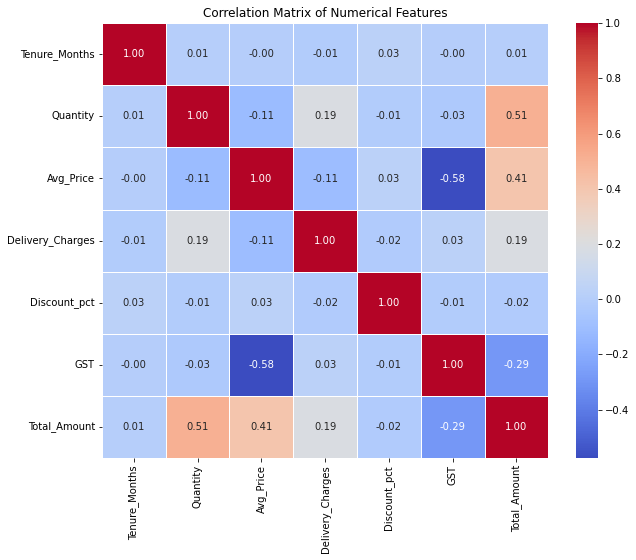

```python
# Visualize the correlation matrix of numerical features
num_cols = ['Tenure_Months', 'Quantity', 'Avg_Price', 'Delivery_Charges', 'Discount_pct', 'GST', 'Total_Amount']
correlation_matrix = sales[num_cols].corr()

# Plot the heatmap
plt.figure(figsize=(10, 8))
sns.heatmap(correlation_matrix, annot=True, cmap='coolwarm', fmt=".2f", linewidths=.5)
plt.title('Correlation Matrix of Numerical Features')
plt.show()
```

Positive Correlation

1.Quantity has a high positive correlation with Total_Amount (Quantity increase - Total amount increase )

2.Quantity has a high positive correlation with Total_Amount (Quantity increase - Total amount increase )

Negative Correlation

1.highly negative correlation between GST (Goods and Services Tax) and Avg_Price could suggest that when the average price of products increases, the amount of GST tends to decrease

2.higher-priced items are more likely to have discounts or be excluded from GST. In some regions, certain products may be exempt from GST or have reduced tax rates.

## 2.Scatter plot between Avg_Price and GST.

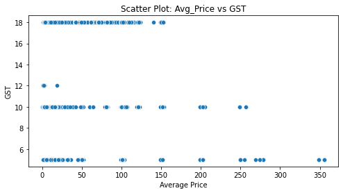

```python
import matplotlib.pyplot as plt
import seaborn as sns

# Scatter plot between Avg_Price and GST
plt.figure(figsize=(8,4))
sns.scatterplot(x='Avg_Price', y='GST', data=sales)
plt.title('Scatter Plot: Avg_Price vs GST')
plt.xlabel('Average Price')
plt.ylabel('GST')
plt.show()
```

The scatter plot indicates an inverse relationship between Avg_Price and GST, suggesting that as average prices rise, GST tends to decrease. This may imply a pricing strategy where higher-priced items incur lower GST percentages or vice versa.

## 3.Distribution of categorical features Gender ,Location , Coupon_Status.

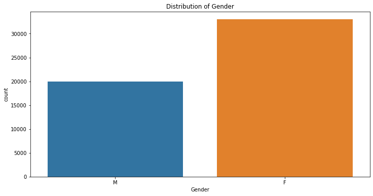

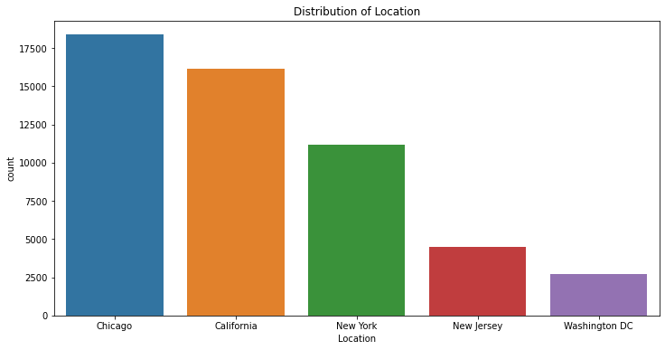

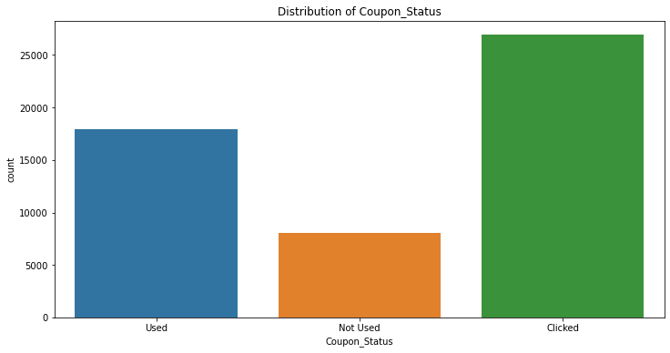

```python
# Distribution of categorical features
cat_cols = ['Gender', 'Location', 'Coupon_Status']
for col in cat_cols:
    plt.figure(figsize=(12,6))
    sns.countplot(x=col, data=sales)
    plt.title(f'Distribution of {col}')
    plt.show()
```

### 1.Gender Distribution:

In terms of gender distribution, the dataset shows a higher representation of women compared to men. Specifically, the total sales attributed to women exceed 30,000, while the total sales associated with men are approximately in the range of 20,000 to 21,000. This suggests that women have a higher contribution to the overall sales in the dataset.

### 2.Location Distribution:

The dataset reveals a notable disparity in customer distribution across various locations, with a substantial number of customers hailing from Chicago and California, each contributing to more than 15,000 transactions. In contrast, customer representation is comparatively lower in New Jersey and Washington DC, where transactions are fewer than 5,000, indicating a lower customer presence in these regions.

### 3.Coupon Status Distribution:

The distribution of coupon statuses in the dataset shows that a significant number of transactions fall into the "Used" category, ranging between 17,000 and 18,000. In contrast, the "Not Used" category has a lower count, with transactions in the range of 7,000 to 8,000. Additionally, the data indicates a high volume of transactions where customers clicked on coupons, surpassing 25,000 transactions.Clicked suggests customer engagement with the coupon, but it does not guarantee that the coupon was applied or resulted in a completed transaction. It provides insights into customer interest or curiosity about the offered discounts or promotions.

## 4.Total sales over time.

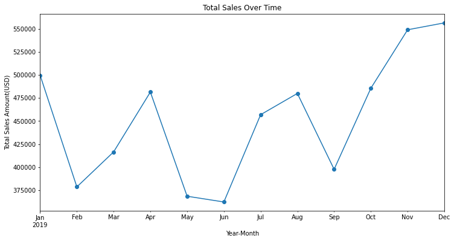

```python
sales['Transaction_Date'] = pd.to_datetime(sales['Transaction_Date'])
sales['Transaction_YearMonth'] = sales['Transaction_Date'].dt.to_period('M')
monthly_sales = sales.groupby('Transaction_YearMonth')['Total_Amount'].sum()

plt.figure(figsize=(12, 6))
monthly_sales.plot(kind='line', marker='o')
plt.title('Total Sales Over Time')
plt.xlabel('Year-Month')
plt.ylabel('Total Sales Amount(USD)')
plt.show()
```

### Total Sales Over Time:

1.The total sales exhibit varying patterns over the months. Notably, from September to January, there is a consistent upward trend, indicating higher total sales amounts during this period.

3.Conversely, May and June show a decrease in total sales, falling below $375,000, indicating a potential dip in consumer spending during these months.

## 5.Total Transactions by Product Category.

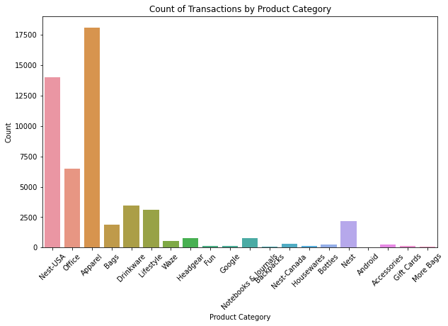

```python
plt.figure(figsize=(10, 6))
sns.countplot(x='Product_Category', data=sales)
plt.title('Count of Transactions by Product Category')
plt.xlabel('Product Category')
plt.xticks(rotation=45)
plt.ylabel('Count')
plt.show()
```

## 6.Total Amount by Product Category.

```python
'''
Display values above the bars

for p in ax.patches:

    ax.annotate(f'${p.get_height():,.2f}', (p.get_x() + p.get_width() / 2., p.get_height()), ha='center', va='center', xytext=(0, 10), textcoords='offset points', fontsize=8)

for p in ax.patches:: This is a loop that iterates through each patch (bar or rectangle) in the ax object. In Matplotlib, a bar chart is typically created using patches.
ax.annotate(...): This function is used to add text annotations to the plot.
f'${p.get_height():,.2f}': This part creates a formatted string that represents the height of the current bar (p.get_height()) in currency format (${:,.2f}). It displays the height with two decimal places and adds a dollar sign.
(p.get_x() + p.get_width() / 2., p.get_height()): Specifies the coordinates where the annotation will be placed. It's positioned at the center of the bar. p.get_x() gives the x-coordinate of the left side of the bar, and p.get_width() / 2 offsets it to the center. p.get_height() provides the y-coordinate of the top of the bar.
ha='center', va='center': These parameters set the horizontal and vertical alignment of the text to the center.
xytext=(0, 10): Specifies the offset of the text from the specified coordinates. In this case, the text is placed 10 points above the center of the bar.
textcoords='offset points': Indicates that the xytext values are specified in points.
fontsize=8: Sets the font size of the annotation text to 8 points.
In summary, this code snippet goes through each bar in the plot and adds an annotation above the center of the bar, displaying the height of the bar in currency format with two decimal places. The annotation is offset 10 points above the bar's center.
'''
```

[output not shown]

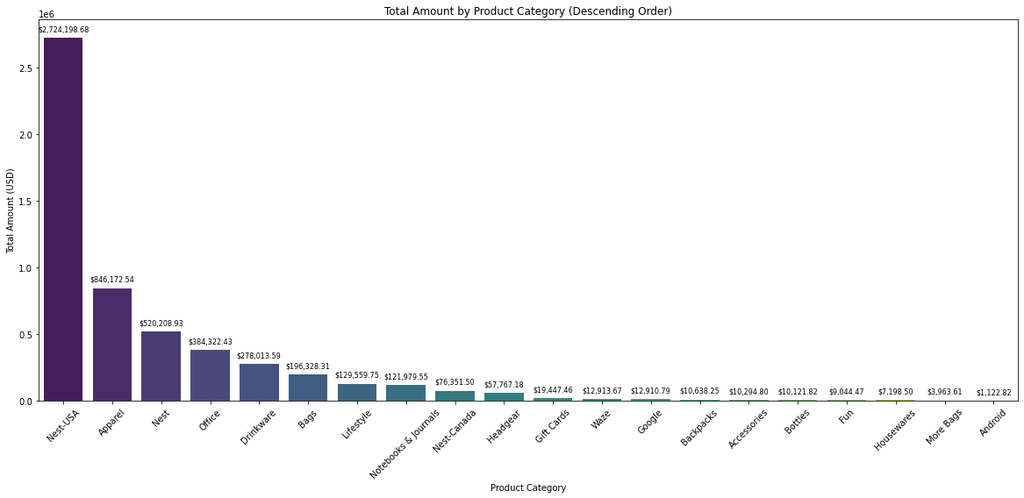

```python
import seaborn as sns
import matplotlib.pyplot as plt

# Assuming 'sales' is your DataFrame
plt.figure(figsize=(20,8))

# Calculate total amount by product category
total_amount_by_category = sales.groupby('Product_Category')['Total_Amount'].sum().reset_index()

# Sort the DataFrame by total amount in descending order
total_amount_by_category = total_amount_by_category.sort_values(by='Total_Amount', ascending=False)

# Create a bar plot
ax = sns.barplot(x='Product_Category', y='Total_Amount', data=total_amount_by_category, palette='viridis')

# Display values above the bars
for p in ax.patches:
    ax.annotate(f'${p.get_height():,.2f}', (p.get_x() + p.get_width() / 2., p.get_height()), ha='center', va='center', xytext=(0, 10), textcoords='offset points', fontsize=8)

plt.title('Total Amount by Product Category (Descending Order)')
plt.xlabel('Product Category')
plt.ylabel('Total Amount (USD)')
plt.xticks(rotation=45)
plt.show()
```

```python
# Calculate total amount by each product category
total_amount_by_category = sales.groupby('Product_Category')['Total_Amount'].sum().reset_index()

# Sort the DataFrame by total amount in descending order
total_amount_by_category = total_amount_by_category.sort_values(by='Total_Amount', ascending=False)

# Print the total amount for each product category
for index, row in total_amount_by_category.iterrows():
    print(f"{row['Product_Category']}: ${row['Total_Amount']:,.2f}")
```

```
Nest-USA: $2,724,198.68
Apparel: $846,172.54
Nest: $520,208.93
Office: $384,322.43
Drinkware: $278,013.59
Bags: $196,328.31
Lifestyle: $129,559.75
Notebooks & Journals: $121,979.55
Nest-Canada: $76,351.50
Headgear: $57,767.18
Gift Cards: $19,447.46
Waze: $12,913.67
Google: $12,910.79
Backpacks: $10,638.25
Accessories: $10,294.80
Bottles: $10,121.82
Fun: $9,044.47
Housewares: $7,198.50
More Bags: $3,963.61
Android: $1,122.82
```

The total sales amount by product category reveals significant contributions from Nest-USA, dominating with 2,724,198.68(USD), followed by strong performances from Apparel (846,172.54(USD)) and Nest (520,208.93(USD)). Other notable categories include Office(384,322.43(USD)), Drinkware(278,013.59(USD)), and Bags(196,328.31(USD)), contributing to the overall sales success. On the contrary, categories like More Bags and Android have relatively lower sales figures.Waze(12,913.67(USD)), Google (12,910.79(USD)),Backpacks(10,638.25(USD)),Accessories(10,294.80(USD)),Bottles(10,121.82(USD)),Fun(9,044.47(USD)),Housewares(7,198.50(USD)),More Bags: (3,963.61(USD)),Android(1,122.82(USD)) have relatively lower sales figures. This breakdown provides insights into the distribution of sales across diverse product categories, highlighting key performers in the dataset.

## 7.Heatmap of Average Discount Percentage by Product Category and Month.

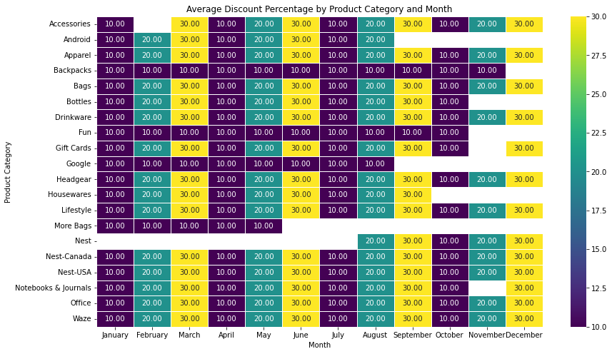

```python
import pandas as pd
import seaborn as sns
import matplotlib.pyplot as plt

# Assuming 'sales' is your DataFrame
# Convert 'Transaction_Date' to datetime
sales['Transaction_Date'] = pd.to_datetime(sales['Transaction_Date'])

# Extract month from 'Transaction_Date'
sales['Transaction_Month'] = sales['Transaction_Date'].dt.month_name()

# Define the order of months
month_order = ['January', 'February', 'March', 'April', 'May', 'June', 'July', 'August', 'September', 'October', 'November', 'December']

# Calculate average discount percentage by product category and month
avg_discount_by_category_month = sales.groupby(['Product_Category', 'Transaction_Month'])['Discount_pct'].mean().reset_index()

# Pivot the data to create a matrix for the heatmap
heatmap_data = avg_discount_by_category_month.pivot(index='Product_Category', columns='Transaction_Month', values='Discount_pct')
heatmap_data = heatmap_data[month_order]  # Reorder columns based on month_order

# Plot the heatmap
plt.figure(figsize=(14, 8))
sns.heatmap(heatmap_data, cmap='viridis', annot=True, fmt=".2f", linewidths=.5)
plt.title('Average Discount Percentage by Product Category and Month')
plt.xlabel('Month')
plt.ylabel('Product Category')
plt.show()
```

Monthly Variation in Discount Percentage by Product Category: Peaks in March, June, September, and December.

## 8.Monthly Distribution of Transactions.

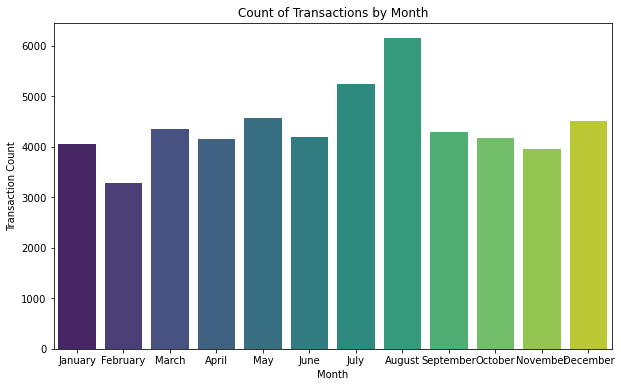

```python
plt.figure(figsize=(10, 6))
sns.countplot(x='Transaction_Month', data=sales, order=['January', 'February', 'March', 'April', 'May', 'June', 'July', 'August', 'September', 'October', 'November', 'December'], palette='viridis')
plt.title('Count of Transactions by Month')
plt.xlabel('Month')
plt.ylabel('Transaction Count')
plt.show()
```

##### Distribution of Monthly Transactions: Peaks in July and August, Medium Activity in May and December, and Similar Levels in Other Months, Low transaction in February.

## 9.Monthly Variation in Total Sales by Product Category.

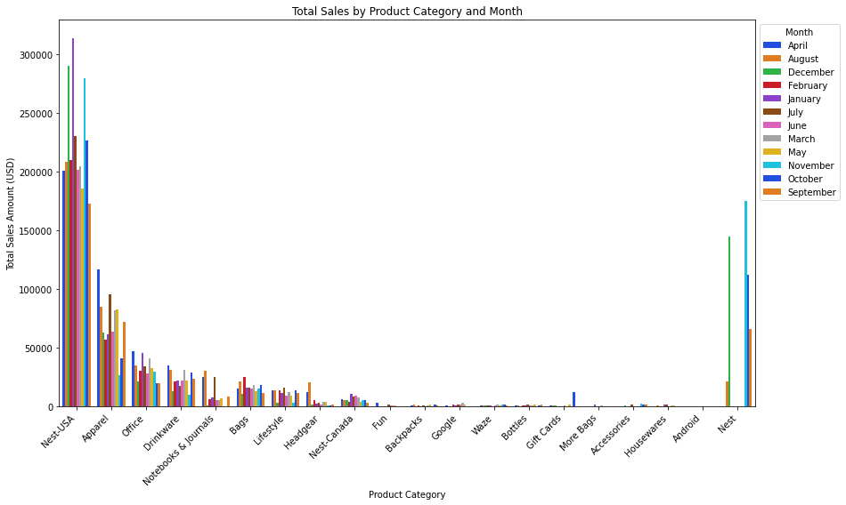

```python
# Calculate total sales by product category and month
total_sales_by_category_month = sales.groupby(['Transaction_Month', 'Product_Category'])['Total_Amount'].sum().reset_index()

# Sort the DataFrame by total sales in descending order
total_sales_by_category_month = total_sales_by_category_month.sort_values(by=['Transaction_Month', 'Total_Amount'], ascending=[True, False])

# Plot the results with a dark color palette
plt.figure(figsize=(14, 8))
sns.barplot(x='Product_Category', y='Total_Amount', hue='Transaction_Month', data=total_sales_by_category_month, palette='bright')
plt.title('Total Sales by Product Category and Month')
plt.xlabel('Product Category')
plt.ylabel('Total Sales Amount (USD)')
plt.xticks(rotation=45, ha='right')
plt.legend(title='Month', bbox_to_anchor=(1, 1))
plt.show()
```

1.Nest USA:

Highs: Nov, Dec, Jan Lows: May, Sept Moderate Activity: Other months

2.Apparel:

Highs: Apr, July Moderate Activity: Mar, May, Aug Decline Post-August: Until Feb

3.Office:

Highs: Jan, March, April Lows: Sept, Oct, Dec Moderate Activity: Other months

4.Nest:

Sales Surge: Aug to Dec Peaks: Nov, Dec Limited Activity: Jan to July

5.Drinkware:

Highs: March, Apr, Oct Lows: Nov, Dec Moderate Activity: Other months

6.Notebook and Journal:

8.Bags, Lifestyle, Headgear, Nest-Canada:

Consistently Low Sales: All months (10,000 to 40,000 USD range)

9.Other Products:

Generally Low Sales: Below 10,000 USD consistently

## 10.Total Amount by Product Category and Gender Heatmap.

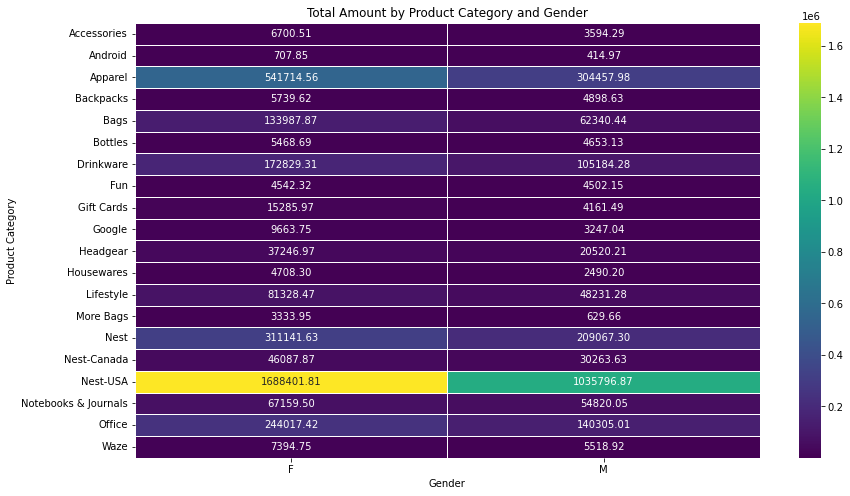

```python
# List of product categories
product_categories = ['Nest-USA', 'Office', 'Apparel', 'Bags', 'Drinkware', 'Lifestyle',
                       'Waze', 'Headgear', 'Fun', 'Google', 'Notebooks & Journals',
                       'Backpacks', 'Nest-Canada', 'Housewares', 'Bottles', 'Nest',
                       'Android', 'Accessories', 'Gift Cards', 'More Bags']

# Calculate total amount by product category, gender, and month
total_amount_by_category_gender = sales.groupby(['Product_Category', 'Gender'])['Total_Amount'].sum().reset_index()

# Filter data for the specified product categories
total_amount_by_category_gender = total_amount_by_category_gender[total_amount_by_category_gender['Product_Category'].isin(product_categories)]

# Pivot the data to create a matrix for the heatmap
heatmap_data = total_amount_by_category_gender.pivot(index='Product_Category', columns='Gender', values='Total_Amount')

# Plot the heatmap
plt.figure(figsize=(14, 8))
sns.heatmap(heatmap_data, cmap='viridis', annot=True, fmt=".2f", linewidths=.5)
plt.title('Total Amount by Product Category and Gender')
plt.xlabel('Gender')
plt.ylabel('Product Category')
plt.show()
```

##### Total Amount by Product Category and Gender Heatmap: High Men's and Women's Spending on NEST USA, Apparel, Nest, and Office; Moderate for Bags, Lifestyle, Headgear, and Nest-Canada; Low for Other Categories. Note: Men's Spending is Generally Lower Compared to Women's Spending on these Products."

## 11.Top 20 Customers by Total Transaction Amount and Location.

```python
import pandas as pd

# Assuming 'sales' is your DataFrame
# You may need to adapt column names based on your actual DataFrame structure

# Group by CustomerID and calculate total transaction amount
customer_transaction_amount = sales.groupby('CustomerID')['Total_Amount'].sum().reset_index()

# Sort by transaction amount in descending order and select the top 20
top_20_customers = customer_transaction_amount.sort_values(by='Total_Amount', ascending=False).head(20)

# Merge with the original DataFrame to get Customer ID, Transaction Amount, and Country
top_20_customers_info = pd.merge(top_20_customers, sales[['CustomerID', 'Location']], on='CustomerID').drop_duplicates()

# Set index from 1 to 20
top_20_customers_info.index = range(1, 21)
print("Top 20 Customers")
# Display the top 20 customers in table format
print(top_20_customers_info[['CustomerID', 'Total_Amount', 'Location']])
```

```
Top 20 Customers
    CustomerID  Total_Amount       Location
1        12748      87549.92        Chicago
2        15311      87207.36        Chicago
3        14606      66445.28        Chicago
4        14911      58781.86     California
5        17841      56007.09     California
6        17850      40875.11        Chicago
7        17337      38034.79     California
8        15039      31969.51        Chicago
9        13089      30799.24     New Jersey
10       14667      30301.69     California
11       15808      28237.56     California
12       13174      24564.97        Chicago
13       18118      24259.09        Chicago
14       14646      24055.30     California
15       14180      23882.31     California
16       13081      23753.52       New York
17       15194      23738.26        Chicago
18       15351      23673.86  Washington DC
19       13113      22542.29     New Jersey
20       12539      20939.85        Chicago
```

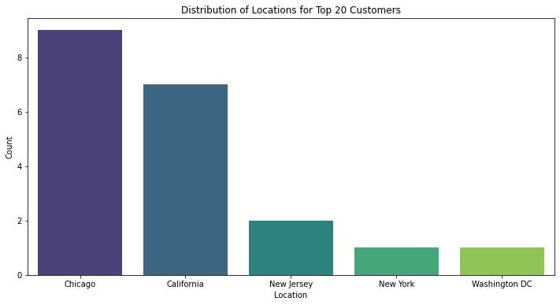

```python
plt.figure(figsize=(12, 6))
sns.countplot(x='Location', data=top_20_customers_info, palette='viridis')
plt.title('Distribution of Locations for Top 20 Customers')
plt.xlabel('Location')
plt.ylabel('Count')
plt.show()
```

##### Top 20 Customers by Total Transaction Amount and Location: Chicago (9), California (7), New Jersey (2), New York (1), Washington DC (1)

## 12.GST by Product Category and Location.

```python
filtered_sales = sales[sales['GST'] < 6]
```

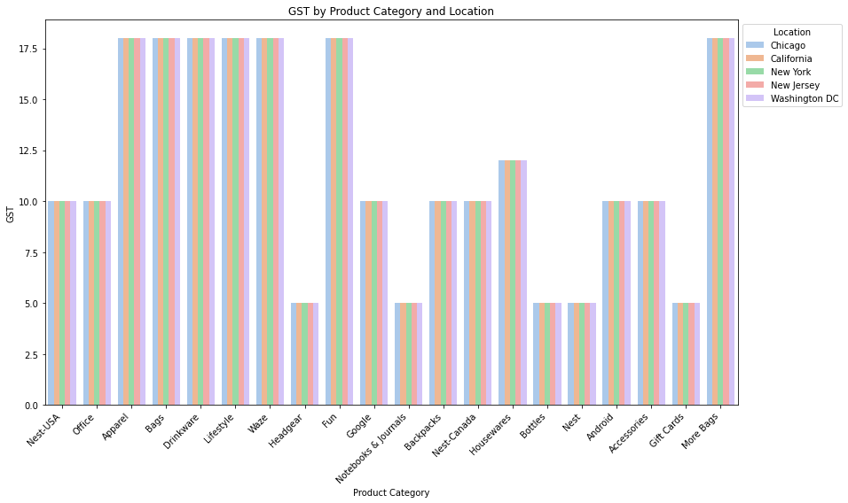

```python
# Create a bar plot for GST by product category and location
plt.figure(figsize=(14, 8))
sns.barplot(x='Product_Category', y='GST', hue='Location', data=sales, ci=None, palette='pastel')
plt.title('GST by Product Category and Location')
plt.xlabel('Product Category')
plt.ylabel('GST')
plt.xticks(rotation=45, ha='right')
plt.legend(title='Location', bbox_to_anchor=(1, 1))
plt.show()
```

## 13.Distribution of Tenure Months by Customer.

```
The number of unique customers is:- 1468
```

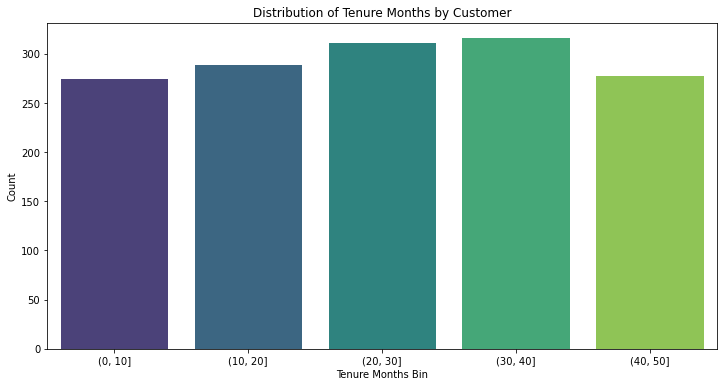

```python
print("The number of unique customers is:-",sales['CustomerID'].nunique())  #nunique() method to count the number of unique customer IDs in the 'CustomerID' column
# Group by CustomerID and calculate the maximum Tenure_Months for each customer
customer_tenure_info = sales.groupby('CustomerID')['Tenure_Months'].max().reset_index()

# Create equal-width bins for Tenure_Months
bins = pd.cut(customer_tenure_info['Tenure_Months'], bins=[0, 10, 20, 30, 40, 50])

# Plot the distribution using a countplot
plt.figure(figsize=(12, 6))
sns.countplot(x=bins, palette='viridis')
plt.title('Distribution of Tenure Months by Customer')
plt.xlabel('Tenure Months Bin')
plt.ylabel('Count')
plt.show()
```

# 5.Machine Learning

Machine learning is a field of artificial intelligence that focuses on the development of algorithms and models that enable computers to learn from and make predictions or decisions based on data, without being explicitly programmed.

```python
df=sales.copy()
```

## 1.Total_Amount Predict Using Linear regression.

```python
from sklearn.model_selection import train_test_split
from sklearn.linear_model import LinearRegression
from sklearn.preprocessing import LabelEncoder
from sklearn.model_selection import cross_val_score
from sklearn.linear_model import LogisticRegression
```

```python
# Label encode categorical columns if needed
label_encoder = LabelEncoder()
```

```python
from sklearn.preprocessing import LabelEncoder

# Columns to encode
columns_to_encode = ['Gender', 'Location', 'Product_Category',"Transaction_Month","Coupon_Status"]

# Dictionary to store mappings
mappings = {}

# Iterate through colu
for column in columns_to_encode:
    label_encoder = LabelEncoder()
    df[column] = label_encoder.fit_transform(df[column])

    # Print the mapping
    print(f"{column} Mapping:")
    column_mapping = dict(zip(label_encoder.classes_, label_encoder.transform(label_encoder.classes_)))
    print(column_mapping)

    # Store the mapping in the dictionary
    mappings[column] = column_mapping

# Display the updated DataFrame
```

```
Gender Mapping:
{'F': 0, 'M': 1}
Location Mapping:
{'California': 0, 'Chicago': 1, 'New Jersey': 2, 'New York': 3, 'Washington DC': 4}
Product_Category Mapping:
{'Accessories': 0, 'Android': 1, 'Apparel': 2, 'Backpacks': 3, 'Bags': 4, 'Bottles': 5, 'Drinkware': 6, 'Fun': 7, 'Gift Cards': 8, 'Google': 9, 'Headgear': 10, 'Housewares': 11, 'Lifestyle': 12, 'More Bags': 13, 'Nest': 14, 'Nest-Canada': 15, 'Nest-USA': 16, 'Notebooks & Journals': 17, 'Office': 18,…
Transaction_Month Mapping:
{'April': 0, 'August': 1, 'December': 2, 'February': 3, 'January': 4, 'July': 5, 'June': 6, 'March': 7, 'May': 8, 'November': 9, 'October': 10, 'September': 11}
Coupon_Status Mapping:
{'Clicked': 0, 'Not Used': 1, 'Used': 2}
```

```python
# Select features (X) and target variable (y)
features = ['Gender', 'Location','Transaction_Month','Product_Category', 'Quantity', 'Avg_Price','Discount_pct',"Coupon_Status"]
X = df[features]
y = df['Total_Amount']

# Split the data into training and testing sets
X_train, X_test, y_train, y_test = train_test_split(X, y, test_size=0.2, random_state=42)

# Initialize the linear regression model
lin_model_ta = LinearRegression()

# Train the model
lin_model_ta.fit(X_train, y_train)

lin_model_ta.score(X_test,y_test)#model.score(X_test,y_test)
```

```
0.4853031046888079
```

```python
X_train.head(2)
```

|  | Gender | Location | Transaction_Month | Product_Category | Quantity | Avg_Price | Discount_pct | Coupon_Status |
| --- | --- | --- | --- | --- | --- | --- | --- | --- |
| 16790 | 1 | 1 | 3 | 16 | 1 | 119.00 | 20.0 | 1 |
| 19679 | 1 | 3 | 1 | 4 | 10 | 79.99 | 20.0 | 1 |

```python
lin_model_ta.predict([[1,0,3,16,100,120,0,2]])
```

```
array([640.50112132])
```

## 2.Coupon_Status Prediction Using LogisticRegression.

```python
from sklearn.linear_model import LogisticRegression

features = ['Gender', 'Location', 'Tenure_Months', 'Quantity', 'Avg_Price', 'Delivery_Charges', 'Discount_pct', 'GST']
X = df[features]
y = df['Coupon_Status']

# Split the data into training and testing sets
X_train, X_test, y_train, y_test = train_test_split(X, y, test_size=0.2, random_state=42)

# Initialize the logistic regression model
log_model = LogisticRegression()

# Train the model
log_model.fit(X_train, y_train)
```

```
LogisticRegression()
```

```python
log_model.score(X_test,y_test)
```

```
0.5111950873878129
```

```python
X_test.head(2)
```

|  | Gender | Location | Tenure_Months | Quantity | Avg_Price | Delivery_Charges | Discount_pct | GST |
| --- | --- | --- | --- | --- | --- | --- | --- | --- |
| 17624 | 1 | 1 | 25 | 1 | 24.99 | 6.50 | 30.0 | 5 |
| 6821 | 0 | 1 | 33 | 2 | 100.91 | 12.99 | 30.0 | 5 |

```python
log_model.predict([[1,1,32,24,100,0,0,5]])
```

```
array([0])
```

### 1.Apply RandomForestClassifier

```python
from sklearn.ensemble import RandomForestClassifier

R_model = RandomForestClassifier(n_estimators=100, random_state=42)

# Train the model
R_model.fit(X_train, y_train)
```

```
RandomForestClassifier(random_state=42)
```

```python
R_model.score(X_test,y_test)
```

```
0.4273972602739726
```

##### RandomForestClassifier Score - 0.42

### 2.Apply KNeighborsClassifier

```python
from sklearn.neighbors import KNeighborsClassifier
K_model = KNeighborsClassifier(n_neighbors=5)
K_model.fit(X_train, y_train)
```

```
KNeighborsClassifier()
```

```python
K_model.score(X_test,y_test)
```

```
0.45092111478507324
```

##### KNeighborsClassifier Score 0.45

### AdaBoostClassifier with LogisticRegression

```python
from sklearn.ensemble import AdaBoostClassifier
base_estimator = LogisticRegression(solver='liblinear', multi_class='ovr')
adb=AdaBoostClassifier(base_estimator=base_estimator, n_estimators=50, random_state=42)
```

```python
cross_val_score(adb, X_train,y_train, cv=3)
```

```
array([0.50811309, 0.50818394, 0.50818394])
```

##### Score - O.50

## 3.Predicting Product_Category using RandomForestClassifier.

```python
import pandas as pd
from sklearn.model_selection import train_test_split
from sklearn.ensemble import RandomForestClassifier
from sklearn.metrics import accuracy_score, classification_report
from sklearn.preprocessing import LabelEncoder

# Assuming your data is stored in a DataFrame named 'df'
# You might need to preprocess your data, handle missing values, and encode categorical variables

# Select features (X) and target variable (y)
features = ['Gender', 'Location', 'Tenure_Months', 'Quantity', 'Avg_Price', 'Delivery_Charges', 'Discount_pct', 'GST']
X = df[features]
y = df['Product_Category']

# Split the data into training and testing sets
X_train, X_test, y_train, y_test = train_test_split(X, y, test_size=0.2, random_state=42)

# Initialize the Random Forest Classifier model
R_model_pc = RandomForestClassifier(n_estimators=100, random_state=42)

# Train the model
R_model_pc.fit(X_train, y_train)

# Make predictions on the test set
predictions = R_model_pc.predict(X_test)

# Evaluate the model
accuracy = accuracy_score(y_test, predictions)
print(f'Accuracy: {accuracy}')

# Print classification report for more detailed evaluation
print(classification_report(y_test, predictions))
```

```
Accuracy: 0.8959848842701936
              precision    recall  f1-score   support

           0       0.45      0.19      0.27        52
           1       0.00      0.00      0.00         7
           2       0.87      0.97      0.91      3583
           3       1.00      0.57      0.72        23
           4       0.72      0.46      0.57       396
           5       0.98      0.98      0.98        47
           6       0.67      0.48      0.56       684
           7       0.41      0.18      0.25        39
           8       1.00      1.00      1.00        34
           9       0.69      0.41      0.51        22
          10       0.80      0.83      0.82       154
          11       1.00      1.00      1.00        21
          12       0.78      0.78      0.78       651
          13       0.50      0.12      0.20         8
          14       1.00      1.00      1.00       450
          15       1.00      0.99      0.99        72
          16       1.00      1.00      1.00      2813
          17       0.80      0.77      0.78       145
          18       0.95      0.99      0.97      1276
          19       0.48      0.22      0.30       108

    accuracy                           0.90     10585
   macro avg       0.76      0.65      0.68     10585
weighted avg       0.89      0.90      0.89     10585
```

```python
R_model_pc.score(X_test,y_test)
```

```
0.8959848842701936
```

```python
R_model_pc.score(X_train,y_train)
```

```
0.9943078485557051
```

```python
R_model_pc.predict([[1,1,22,10,119,8,20,0]])
```

```
array([14])
```

# 6.Neural Network

A neural network is a computational model inspired by the structure and functioning of the human brain, composed of interconnected nodes (neurons) arranged in layers. It is used in machine learning to recognize patterns, make predictions, and perform tasks by learning from data through iterative training processes.

## Product Category Prediction with Neural Network.

1.This script demonstrates building and training a neural network for product category prediction.

2.It uses features like Gender, Location, Tenure_Months, Quantity, Avg_Price, etc., to predict the product category.

3.The model is trained using TensorFlow and Keras, and evaluated using accuracy and classification report.

4.Code snippet taken from ChatGPT.

```python
import tensorflow as tf
import pandas as pd
from sklearn.model_selection import train_test_split
from sklearn.preprocessing import LabelEncoder
from sklearn.metrics import accuracy_score
from tensorflow.keras.models import Sequential
from tensorflow.keras.layers import Dense
from tensorflow.keras.optimizers import Adam
```

[output not shown]

```python
# Assuming your data is stored in a DataFrame named 'df'
# You might need to preprocess your data, handle missing values, etc.

# Specify the features and target variable
features = ['Gender', 'Location', 'Tenure_Months', 'Quantity', 'Avg_Price', 'Delivery_Charges', 'Discount_pct', 'GST']
target_variable = 'Product_Category'

# Extract features and target variable
X = df[features]
y = df[target_variable]

# Label encode the target variable
label_encoder = LabelEncoder()
y = label_encoder.fit_transform(y)

# Split the data into training and testing sets
X_train, X_test, y_train, y_test = train_test_split(X, y, test_size=0.2, random_state=42)
```

```python
# Build the neural network model
model = Sequential()
model.add(Dense(64, input_dim=len(features), activation='relu'))
model.add(Dense(32, activation='relu'))
model.add(Dense(len(label_encoder.classes_), activation='softmax'))  # Output layer with softmax for classification
```

[output not shown]

```python
# Compile the model
model.compile(loss='sparse_categorical_crossentropy', optimizer=Adam(), metrics=['accuracy'])

# Train the model
model.fit(X_train, y_train, epochs=10, batch_size=32, validation_split=0.2)
```

[output not shown]

```
<keras.src.callbacks.History at 0x217c86c8f10>
```

```python
# Make predictions on the test set
y_pred = model.predict(X_test)
y_pred_classes = y_pred.argmax(axis=-1)
```

```python
# Inverse transform the encoded predictions to get the original classes
y_pred_original = label_encoder.inverse_transform(y_pred_classes)
```

```python
# Evaluate the model
accuracy = accuracy_score(y_test, y_pred_classes)
print(f'Accuracy: {accuracy}')
```

```
Accuracy: 0.8353330184222957
```

```python
X_test.head(2)
```

|  | Gender | Location | Tenure_Months | Quantity | Avg_Price | Delivery_Charges | Discount_pct | GST |
| --- | --- | --- | --- | --- | --- | --- | --- | --- |
| 17624 | 1 | 1 | 25 | 1 | 24.99 | 6.50 | 30.0 | 5 |
| 6821 | 0 | 1 | 33 | 2 | 100.91 | 12.99 | 30.0 | 5 |

##### Pedict Product

```python
new_input = [[1, 1, 25, 1, 24.99, 6.50, 30, 5]]

# Make predictions for the new input
new_input_predictions = model.predict(new_input)
new_input_class = new_input_predictions.argmax(axis=-1)[0]

# Inverse transform the encoded prediction to get the original product category
new_input_original_category = label_encoder.inverse_transform([new_input_class])[0]

# Print the predicted product category
print("Predicted Product Category for Input:", new_input_original_category)
```

```
Predicted Product Category for Input: 10
```

##### Headgear: 10

### Product Category Prediction with Multiple Classifiers

1.Product Category Prediction with Multiple Classifiers (Code Commented due to Extended Execution Time) 2.This script demonstrates using RandomForest, Support Vector Machine (SVM), and k-Nearest Neighbors (kNN) 3.classifiers for product category prediction. Features like Gender, Location, Tenure_Months, Quantity, Avg_Price, etc., are used. 4.Cross-validation is performed to evaluate classifiers, but the actual training and testing code is commented to reduce execution time.

```python
'''
import pandas as pd
from sklearn.model_selection import cross_val_score, train_test_split
from sklearn.ensemble import RandomForestClassifier
from sklearn.svm import SVC
from sklearn.neighbors import KNeighborsClassifier
from sklearn.preprocessing import LabelEncoder
from sklearn.metrics import accuracy_score

# Assuming your data is stored in a DataFrame named 'df'
# You might need to preprocess your data, handle missing values, and encode categorical variables

# Example of preprocessing for demonstration purposes
# Label encode categorical columns if needed

# Select features (X) and target variable (y)
features = ['Gender', 'Location', 'Tenure_Months', 'Quantity', 'Avg_Price', 'Delivery_Charges', 'Discount_pct', 'GST']
X = df[features]
y = df['Product_Category']

# Split the data into training and testing sets
X_train, X_test, y_train, y_test = train_test_split(X, y, test_size=0.2, random_state=42)

# Initialize classifiers
rf_classifier = RandomForestClassifier(n_estimators=100, random_state=42)
svm_classifier = SVC(kernel='linear', random_state=42)
knn_classifier = KNeighborsClassifier(n_neighbors=5)

# List of classifiers
classifiers = [rf_classifier, svm_classifier, knn_classifier]

# Perform cross-validation and print accuracy scores for each classifier
for classifier in classifiers:
    scores = cross_val_score(classifier, X, y, cv=3)
    print(f"Accuracy for {classifier.__class__.__name__}: {scores.mean()}")

# If you want to check accuracy on a specific test set
for classifier in classifiers:
    classifier.fit(X_train, y_train)
    predictions = classifier.predict(X_test)
    accuracy = accuracy_score(y_test, predictions)
    print(f"Accuracy on test set for {classifier.__class__.__name__}: {accuracy}")

'''
```